# Unsupervised_Learning_Project_Part1

## Importing the Libraries

```python
## Pandas and Numpy

import pandas as pd
import numpy as np

## Plotting libraries

import matplotlib.pyplot as plt
import seaborn as sns

## Ignore warnings

import warnings
warnings.filterwarnings('ignore')

## Stats Libraries

from scipy.stats import zscore
from scipy.stats import chisquare

import statsmodels.api as sm
from statsmodels.formula.api import ols

## Machine Learning Libraries

from sklearn.model_selection import train_test_split
from sklearn.cluster import AgglomerativeClustering
from sklearn.cluster import KMeans
from sklearn.decomposition import PCA
from sklearn.linear_model import LinearRegression
from sklearn.metrics import r2_score
```

## Importing the dataset

```python
df1 = pd.read_json("Part1 - Car-Attributes.json")
df2 = pd.read_csv("Part1 - Car name.csv")
```

#### Exploring the datasets

```python
df1.shape
```

```
(398, 8)
```

```python
df2.shape
```

```
(398, 1)
```

```python
df1.head()
```

|  | mpg | cyl | disp | hp | wt | acc | yr | origin |
| --- | --- | --- | --- | --- | --- | --- | --- | --- |
| 0 | 18.0 | 8 | 307.0 | 130 | 3504 | 12.0 | 70 | 1 |
| 1 | 15.0 | 8 | 350.0 | 165 | 3693 | 11.5 | 70 | 1 |
| 2 | 18.0 | 8 | 318.0 | 150 | 3436 | 11.0 | 70 | 1 |
| 3 | 16.0 | 8 | 304.0 | 150 | 3433 | 12.0 | 70 | 1 |
| 4 | 17.0 | 8 | 302.0 | 140 | 3449 | 10.5 | 70 | 1 |

```python
df2.head()
```

|  | car_name |
| --- | --- |
| 0 | chevrolet chevelle malibu |
| 1 | buick skylark 320 |
| 2 | plymouth satellite |
| 3 | amc rebel sst |
| 4 | ford torino |

#### Merging the datasets

```python
df = df1.merge(df2, right_index=True, left_index= True)
```

```python
df.shape
```

```
(398, 9)
```

```python
df.head()
```

|  | mpg | cyl | disp | hp | wt | acc | yr | origin | car_name |
| --- | --- | --- | --- | --- | --- | --- | --- | --- | --- |
| 0 | 18.0 | 8 | 307.0 | 130 | 3504 | 12.0 | 70 | 1 | chevrolet chevelle malibu |
| 1 | 15.0 | 8 | 350.0 | 165 | 3693 | 11.5 | 70 | 1 | buick skylark 320 |
| 2 | 18.0 | 8 | 318.0 | 150 | 3436 | 11.0 | 70 | 1 | plymouth satellite |
| 3 | 16.0 | 8 | 304.0 | 150 | 3433 | 12.0 | 70 | 1 | amc rebel sst |
| 4 | 17.0 | 8 | 302.0 | 140 | 3449 | 10.5 | 70 | 1 | ford torino |

#### Exporting the dataframe into .csv, .xlsx, .json formats

```python
df.to_csv('Cars.csv', index = False)
df.to_excel('Cars.xlsx', index = False)
df.to_json('Cars.json')
```

```python
## Importing data from the file created in the previous steps

df = pd.read_json('Cars.json')
```

```python
df.shape
```

```
(398, 9)
```

```python
df.head()
```

|  | mpg | cyl | disp | hp | wt | acc | yr | origin | car_name |
| --- | --- | --- | --- | --- | --- | --- | --- | --- | --- |
| 0 | 18.0 | 8 | 307.0 | 130 | 3504 | 12.0 | 70 | 1 | chevrolet chevelle malibu |
| 1 | 15.0 | 8 | 350.0 | 165 | 3693 | 11.5 | 70 | 1 | buick skylark 320 |
| 2 | 18.0 | 8 | 318.0 | 150 | 3436 | 11.0 | 70 | 1 | plymouth satellite |
| 3 | 16.0 | 8 | 304.0 | 150 | 3433 | 12.0 | 70 | 1 | amc rebel sst |
| 4 | 17.0 | 8 | 302.0 | 140 | 3449 | 10.5 | 70 | 1 | ford torino |

## Missing/ Incorrect value treatment

```python
df.info()
```

```
<class 'pandas.core.frame.DataFrame'>
Int64Index: 398 entries, 0 to 397
Data columns (total 9 columns):
 #   Column    Non-Null Count  Dtype
---  ------    --------------  -----
 0   mpg       398 non-null    float64
 1   cyl       398 non-null    int64
 2   disp      398 non-null    float64
 3   hp        398 non-null    object
 4   wt        398 non-null    int64
 5   acc       398 non-null    float64
 6   yr        398 non-null    int64
 7   origin    398 non-null    int64
 8   car_name  398 non-null    object
dtypes: float64(3), int64(4), object(2)
memory usage: 31.1+ KB
```

#### There are no null values. However, hp is supposed to be a numeric and continuous variable. Since it is an object some observations might be non numeric

```python
df[df.hp.str.isdigit()==False]
```

|  | mpg | cyl | disp | hp | wt | acc | yr | origin | car_name |
| --- | --- | --- | --- | --- | --- | --- | --- | --- | --- |
| 32 | 25.0 | 4 | 98.0 | ? | 2046 | 19.0 | 71 | 1 | ford pinto |
| 126 | 21.0 | 6 | 200.0 | ? | 2875 | 17.0 | 74 | 1 | ford maverick |
| 330 | 40.9 | 4 | 85.0 | ? | 1835 | 17.3 | 80 | 2 | renault lecar deluxe |
| 336 | 23.6 | 4 | 140.0 | ? | 2905 | 14.3 | 80 | 1 | ford mustang cobra |
| 354 | 34.5 | 4 | 100.0 | ? | 2320 | 15.8 | 81 | 2 | renault 18i |
| 374 | 23.0 | 4 | 151.0 | ? | 3035 | 20.5 | 82 | 1 | amc concord dl |

```python
## replacing '?' with NaN to further replace with a measure of central tendency

df.hp = df.hp.replace('?',np.nan)
```

```python
df.info()
```

```
<class 'pandas.core.frame.DataFrame'>
Int64Index: 398 entries, 0 to 397
Data columns (total 9 columns):
 #   Column    Non-Null Count  Dtype
---  ------    --------------  -----
 0   mpg       398 non-null    float64
 1   cyl       398 non-null    int64
 2   disp      398 non-null    float64
 3   hp        392 non-null    float64
 4   wt        398 non-null    int64
 5   acc       398 non-null    float64
 6   yr        398 non-null    int64
 7   origin    398 non-null    int64
 8   car_name  398 non-null    object
dtypes: float64(4), int64(4), object(1)
memory usage: 31.1+ KB
```

```python
df.median()
```

```
mpg         23.0
cyl          4.0
disp       148.5
hp          93.5
wt        2803.5
acc         15.5
yr          76.0
origin       1.0
dtype: float64
```

```python
## Replacing NaN values with the median of the variable hp

df.hp = df.hp.replace(np.nan,93.5)
```

```python
df.head()
```

|  | mpg | cyl | disp | hp | wt | acc | yr | origin | car_name |
| --- | --- | --- | --- | --- | --- | --- | --- | --- | --- |
| 0 | 18.0 | 8 | 307.0 | 130.0 | 3504 | 12.0 | 70 | 1 | chevrolet chevelle malibu |
| 1 | 15.0 | 8 | 350.0 | 165.0 | 3693 | 11.5 | 70 | 1 | buick skylark 320 |
| 2 | 18.0 | 8 | 318.0 | 150.0 | 3436 | 11.0 | 70 | 1 | plymouth satellite |
| 3 | 16.0 | 8 | 304.0 | 150.0 | 3433 | 12.0 | 70 | 1 | amc rebel sst |
| 4 | 17.0 | 8 | 302.0 | 140.0 | 3449 | 10.5 | 70 | 1 | ford torino |

```python
## Dropping Car Name as it would not serve any purpose in the problem solving process

df = df.drop(['car_name'], axis = 1)
```

```python
## Giving identifiable names to the categories of origin variable

df['origin'] = df['origin'].replace({1: 'America', 2: 'Europe', 3: 'Asia'})
```

```python
df.info()
```

```
<class 'pandas.core.frame.DataFrame'>
Int64Index: 398 entries, 0 to 397
Data columns (total 8 columns):
 #   Column  Non-Null Count  Dtype
---  ------  --------------  -----
 0   mpg     398 non-null    float64
 1   cyl     398 non-null    int64
 2   disp    398 non-null    float64
 3   hp      398 non-null    float64
 4   wt      398 non-null    int64
 5   acc     398 non-null    float64
 6   yr      398 non-null    int64
 7   origin  398 non-null    object
dtypes: float64(4), int64(3), object(1)
memory usage: 28.0+ KB
```

#### Although year and origin should actually be treated as categorical variables, we see through scatter and box plots that they are important variables from the perspective of explaining the target variable mpg

## Data Analysis and Visualization

```python
df.columns
```

```
Index(['mpg', 'cyl', 'disp', 'hp', 'wt', 'acc', 'yr', 'origin'], dtype='object')
```

##### Analyzing the variable 'cyl' - no. of cylinders

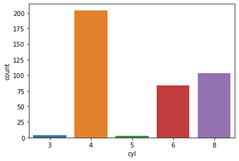

```python
sns.countplot(df.cyl);
```

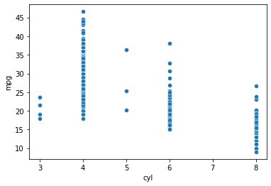

```python
sns.scatterplot(df.cyl,df.mpg);
```

##### Although 'cyl' is a discrete variable for the purposes of solving the problem at hand we can consider it to be continuous.

```python
print('Correlation between cyl and mpg is',round(df.cyl.corr(df.mpg),2))
```

```
Correlation between cyl and mpg is -0.78
```

We see that cyl and mpg have a strong negative correlation

```python
df.columns
```

```
Index(['mpg', 'cyl', 'disp', 'hp', 'wt', 'acc', 'yr', 'origin'], dtype='object')
```

##### Analyzing the variable 'disp' - displacement

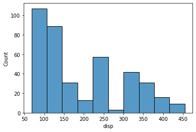

```python
sns.histplot(df.disp);
```

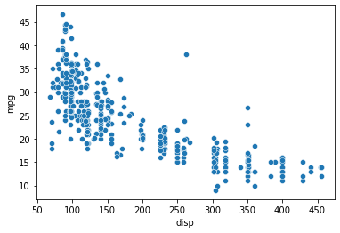

```python
sns.scatterplot(df.disp,df.mpg);
```

```python
print('Correlation between disp and mpg is',round(df.disp.corr(df.mpg),2))
```

```
Correlation between disp and mpg is -0.8
```

We see that disp and mpg have a strong negative correlation

##### Analyzing the variable 'hp' - horsepower

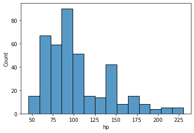

```python
sns.histplot(df.hp);
```

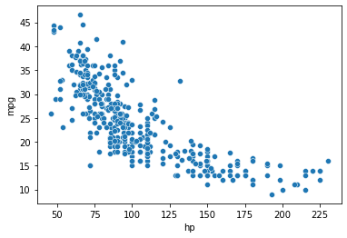

```python
sns.scatterplot(df.hp,df.mpg);
```

```python
print('Correlation between hp and mpg is',round(df.hp.corr(df.mpg),2))
```

```
Correlation between hp and mpg is -0.77
```

We see that hp and mpg have a strong negative correlation

```python
df.columns
```

```
Index(['mpg', 'cyl', 'disp', 'hp', 'wt', 'acc', 'yr', 'origin'], dtype='object')
```

##### Analyzing 'wt' - weight

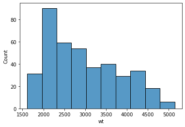

```python
sns.histplot(df.wt);
```

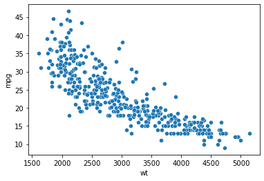

```python
sns.scatterplot(df.wt,df.mpg);
```

```python
print('Correlation between wt and mpg is',round(df.wt.corr(df.mpg),2))
```

```
Correlation between wt and mpg is -0.83
```

We see that wt and mpg have a strong negative correlation

##### Analyzing 'acc' - acceleration

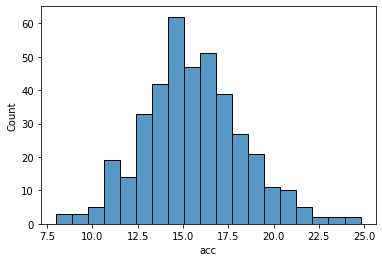

```python
sns.histplot(df.acc);
```

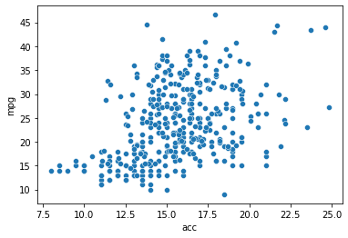

```python
sns.scatterplot(df.acc,df.mpg);
```

```python
print('Correlation between wt and mpg is',round(df.acc.corr(df.mpg),2))
```

```
Correlation between wt and mpg is 0.42
```

We see that acc and mpg have a moderate positive correlation

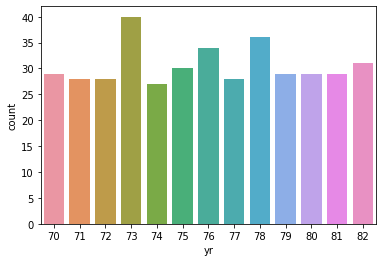

```python
sns.countplot(df.yr);
```

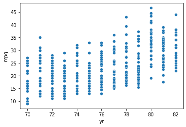

```python
sns.scatterplot(df.yr,df.mpg);
```

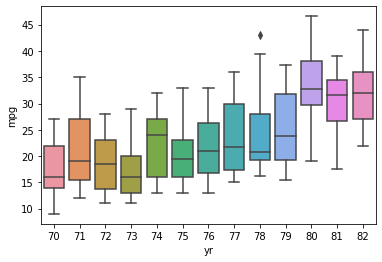

```python
sns.boxplot(df.yr,df.mpg);
```

We see that the cars made in the later years have better mileage on an average

##### Analyzing Origin

```python
dfscaled = df.iloc[:,:-1].apply(zscore)
```

```python
dfscaled
```

|  | mpg | cyl | disp | hp | wt | acc | yr |
| --- | --- | --- | --- | --- | --- | --- | --- |
| 0 | -0.706439 | 1.498191 | 1.090604 | 0.673118 | 0.630870 | -1.295498 | -1.627426 |
| 1 | -1.090751 | 1.498191 | 1.503514 | 1.589958 | 0.854333 | -1.477038 | -1.627426 |
| 2 | -0.706439 | 1.498191 | 1.196232 | 1.197027 | 0.550470 | -1.658577 | -1.627426 |
| 3 | -0.962647 | 1.498191 | 1.061796 | 1.197027 | 0.546923 | -1.295498 | -1.627426 |
| 4 | -0.834543 | 1.498191 | 1.042591 | 0.935072 | 0.565841 | -1.840117 | -1.627426 |
| ... | ... | ... | ... | ... | ... | ... | ... |
| 393 | 0.446497 | -0.856321 | -0.513026 | -0.479482 | -0.213324 | 0.011586 | 1.621983 |
| 394 | 2.624265 | -0.856321 | -0.925936 | -1.370127 | -0.993671 | 3.279296 | 1.621983 |
| 395 | 1.087017 | -0.856321 | -0.561039 | -0.531873 | -0.798585 | -1.440730 | 1.621983 |
| 396 | 0.574601 | -0.856321 | -0.705077 | -0.662850 | -0.408411 | 1.100822 | 1.621983 |
| 397 | 0.958913 | -0.856321 | -0.714680 | -0.584264 | -0.296088 | 1.391285 | 1.621983 |

398 rows × 7 columns

```python
dfscaled = pd.concat([dfscaled.reset_index(drop=True), df.iloc[:,-1]], axis=1)
```

```python
dfscaled
```

|  | mpg | cyl | disp | hp | wt | acc | yr | origin |
| --- | --- | --- | --- | --- | --- | --- | --- | --- |
| 0 | -0.706439 | 1.498191 | 1.090604 | 0.673118 | 0.630870 | -1.295498 | -1.627426 | America |
| 1 | -1.090751 | 1.498191 | 1.503514 | 1.589958 | 0.854333 | -1.477038 | -1.627426 | America |
| 2 | -0.706439 | 1.498191 | 1.196232 | 1.197027 | 0.550470 | -1.658577 | -1.627426 | America |
| 3 | -0.962647 | 1.498191 | 1.061796 | 1.197027 | 0.546923 | -1.295498 | -1.627426 | America |
| 4 | -0.834543 | 1.498191 | 1.042591 | 0.935072 | 0.565841 | -1.840117 | -1.627426 | America |
| ... | ... | ... | ... | ... | ... | ... | ... | ... |
| 393 | 0.446497 | -0.856321 | -0.513026 | -0.479482 | -0.213324 | 0.011586 | 1.621983 | America |
| 394 | 2.624265 | -0.856321 | -0.925936 | -1.370127 | -0.993671 | 3.279296 | 1.621983 | Europe |
| 395 | 1.087017 | -0.856321 | -0.561039 | -0.531873 | -0.798585 | -1.440730 | 1.621983 | America |
| 396 | 0.574601 | -0.856321 | -0.705077 | -0.662850 | -0.408411 | 1.100822 | 1.621983 | America |
| 397 | 0.958913 | -0.856321 | -0.714680 | -0.584264 | -0.296088 | 1.391285 | 1.621983 | America |

398 rows × 8 columns

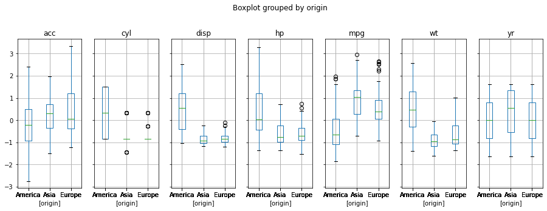

```python
dfscaled.boxplot(by = 'origin', layout= (2,7), figsize=(15,10));
```

With the above plot we see that cars of American origin have quite different attributes compared to cars from Asia and Europe

##### Multivariate Analysis

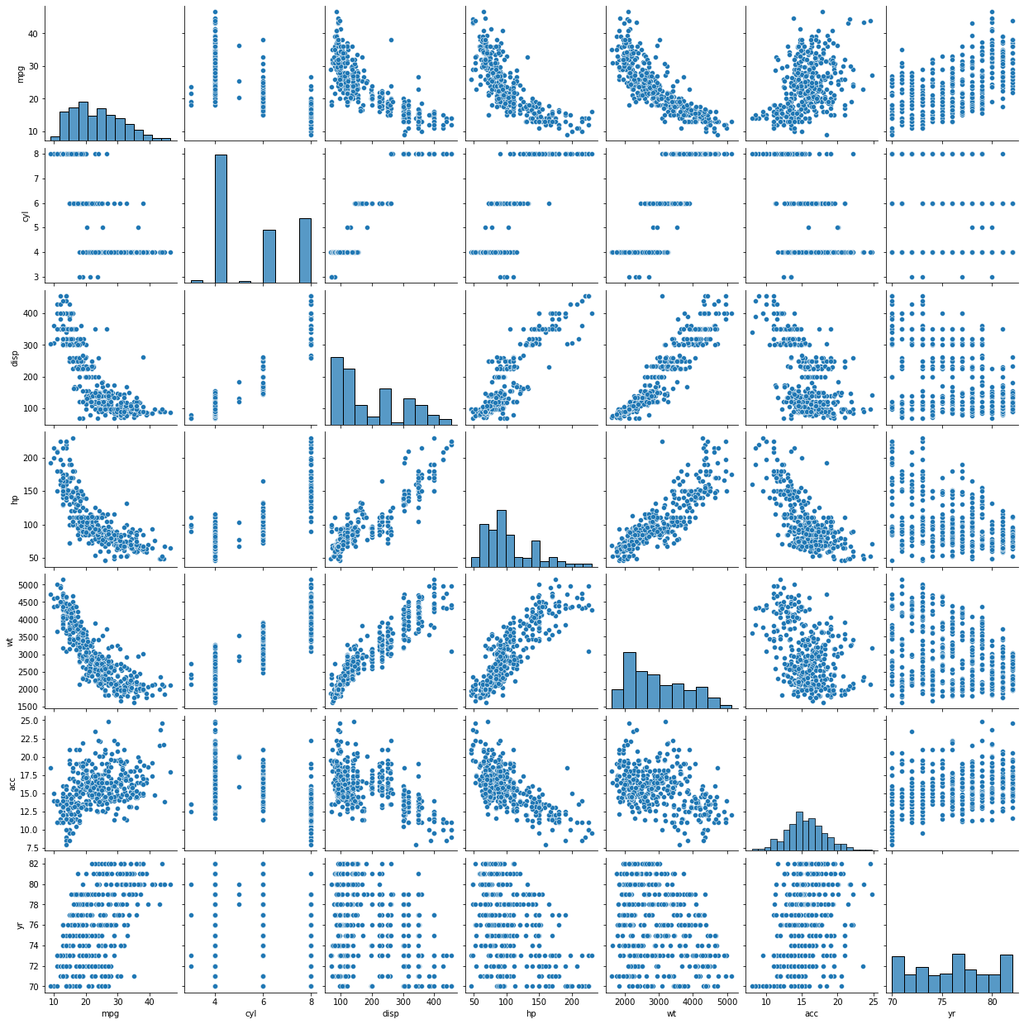

```python
sns.pairplot(df);
```

```python
df.columns
```

```
Index(['mpg', 'cyl', 'disp', 'hp', 'wt', 'acc', 'yr', 'origin'], dtype='object')
```

##### One observation from the pairplots is that as no. of cylinders, the hp and disp increases acc falls. That is counter intuitive. In an ideal scenario number of cylinders, hp and acc should be positively correlated

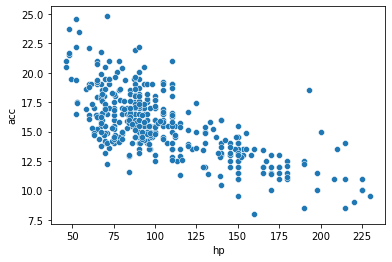

```python
sns.scatterplot(df.hp,df.acc);
```

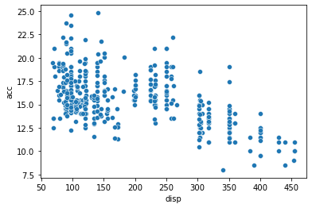

```python
sns.scatterplot(df.disp,df.acc);
```

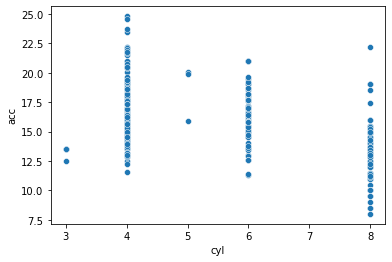

```python
sns.scatterplot(df.cyl,df.acc);
```

```python
print('Correlation between hp and acc is',round(df.hp.corr(df.acc),2))
print('Correlation between disp and acc is',round(df.disp.corr(df.acc),2))
print('Correlation between disp and acc is',round(df.cyl.corr(df.acc),2))
```

```
Correlation between hp and acc is -0.69
Correlation between disp and acc is -0.54
Correlation between disp and acc is -0.51
```

##### Therefore there may be other reasons that may be affecting acceleration and causing a reduction in acceleration despite higher hp and disp

##### One possible reason may be the weight of the cars

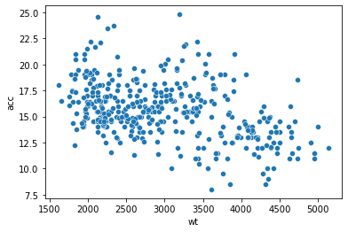

```python
sns.scatterplot(df.wt,df.acc);
```

```python
print('Correlation between wt and acc is',round(df.hp.corr(df.acc),2))
```

[output not shown]

```python
df['acc_by_disp'] = df.acc/df.disp
```

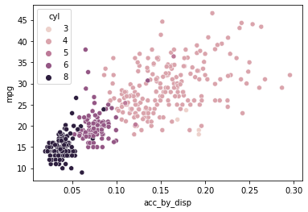

```python
sns.scatterplot(df.acc_by_disp,df.mpg, hue = df.cyl);
```

```python
df
```

|  | mpg | cyl | disp | hp | wt | acc | yr | origin | acc_by_disp |
| --- | --- | --- | --- | --- | --- | --- | --- | --- | --- |
| 0 | 18.0 | 8 | 307.0 | 130.0 | 3504 | 12.0 | 70 | America | 0.039088 |
| 1 | 15.0 | 8 | 350.0 | 165.0 | 3693 | 11.5 | 70 | America | 0.032857 |
| 2 | 18.0 | 8 | 318.0 | 150.0 | 3436 | 11.0 | 70 | America | 0.034591 |
| 3 | 16.0 | 8 | 304.0 | 150.0 | 3433 | 12.0 | 70 | America | 0.039474 |
| 4 | 17.0 | 8 | 302.0 | 140.0 | 3449 | 10.5 | 70 | America | 0.034768 |
| ... | ... | ... | ... | ... | ... | ... | ... | ... | ... |
| 393 | 27.0 | 4 | 140.0 | 86.0 | 2790 | 15.6 | 82 | America | 0.111429 |
| 394 | 44.0 | 4 | 97.0 | 52.0 | 2130 | 24.6 | 82 | Europe | 0.253608 |
| 395 | 32.0 | 4 | 135.0 | 84.0 | 2295 | 11.6 | 82 | America | 0.085926 |
| 396 | 28.0 | 4 | 120.0 | 79.0 | 2625 | 18.6 | 82 | America | 0.155000 |
| 397 | 31.0 | 4 | 119.0 | 82.0 | 2720 | 19.4 | 82 | America | 0.163025 |

398 rows × 9 columns

##### Combinations of other attributes were also checked but nothing significant was observed except the importance of weight on all variables including mpg